# IODS course project

# Analysis exercise 5: Dimensionality reduction

```r
date()
```

```
## [1] "Mon Dec 12 19:22:13 2022"
```

This time we are exploring a dataset called “human” which consists of human development index (HDI) data and various variables that are used to calcualte the HDI. On https://hdr.undp.org/data-center/human-development-index#/indicies/HDI the HDI is described thus:

“The Human Development Index (HDI) is a summary measure of average achievement in key dimensions of human development: a long and healthy life, being knowledgeable and have a decent standard of living. The HDI is the geometric mean of normalized indices for each of the three dimensions.”

Let’s first get a brief overview of the data.

```r
library(tidyverse)
library(readr)
human <- read.table(file = 'C:/IODS/IODS-project/data/human2.txt')
str(human)
```

```
## 'data.frame':    155 obs. of  8 variables:
##  $ labforc_r : num  0.891 0.819 0.825 0.884 0.829 ...
##  $ sec_edu_r : num  1.007 0.997 0.983 0.989 0.969 ...
##  $ Exp_yr_edu: num  17.5 20.2 15.8 18.7 17.9 16.5 18.6 16.5 15.9 19.2 ...
##  $ Life_exp  : num  81.6 82.4 83 80.2 81.6 80.9 80.9 79.1 82 81.8 ...
##  $ GNI       : int  64992 42261 56431 44025 45435 43919 39568 52947 42155 32689 ...
##  $ Mat_mort_r: int  4 6 6 5 6 7 9 28 11 8 ...
##  $ Ad_birth_r: num  7.8 12.1 1.9 5.1 6.2 3.8 8.2 31 14.5 25.3 ...
##  $ X.rep_parl: num  39.6 30.5 28.5 38 36.9 36.9 19.9 19.4 28.2 31.4 ...
```

```r
dim(human)
```

```
## [1] 155   8
```

The data consists of 155 observations (in this case countries) and 8 variables named:

labforc_r : Labour Force Participation Rate ratio between males and females sec_edu_r : Population with Secondary Education ratio between males and females Exp_yr_edu: Expected Years of Education Life_exp : Life Expectancy at Birth GNI : Gross National Income (GNI) per Capita Mat_mort_r: Maternal Mortality Ratio Ad_birth_r: Adolescent Birth Rate X.rep_parl: Percent Representation in Parliament

Next, let’s summarize the data and get a graphical overview:

```r
summary(human)
```

```
##    labforc_r        sec_edu_r        Exp_yr_edu       Life_exp
##  Min.   :0.1857   Min.   :0.1717   Min.   : 5.40   Min.   :49.00
##  1st Qu.:0.5984   1st Qu.:0.7264   1st Qu.:11.25   1st Qu.:66.30
##  Median :0.7535   Median :0.9375   Median :13.50   Median :74.20
##  Mean   :0.7074   Mean   :0.8529   Mean   :13.18   Mean   :71.65
##  3rd Qu.:0.8535   3rd Qu.:0.9968   3rd Qu.:15.20   3rd Qu.:77.25
##  Max.   :1.0380   Max.   :1.4967   Max.   :20.20   Max.   :83.50
##       GNI           Mat_mort_r       Ad_birth_r       X.rep_parl
##  Min.   :   581   Min.   :   1.0   Min.   :  0.60   Min.   : 0.00
##  1st Qu.:  4198   1st Qu.:  11.5   1st Qu.: 12.65   1st Qu.:12.40
##  Median : 12040   Median :  49.0   Median : 33.60   Median :19.30
##  Mean   : 17628   Mean   : 149.1   Mean   : 47.16   Mean   :20.91
##  3rd Qu.: 24512   3rd Qu.: 190.0   3rd Qu.: 71.95   3rd Qu.:27.95
##  Max.   :123124   Max.   :1100.0   Max.   :204.80   Max.   :57.50
```

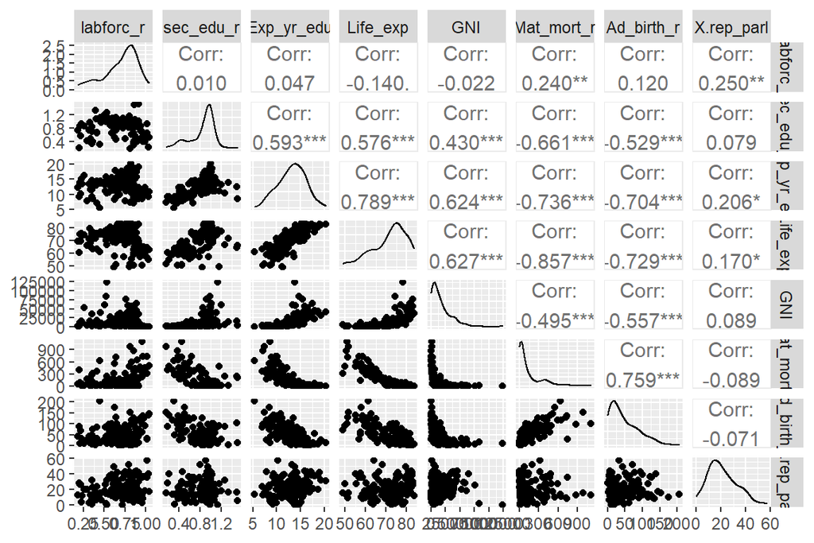

```r
library(ggplot2)
library(dplyr)
library(GGally)
p <- ggpairs(human, lower = list(combo = wrap("facethist", bins = 20)))
p
```

The variables seem to not be very normally distributed and seem to contain many outliers.

The relations between the datapoints can be further explored by making a simple correlation plot:

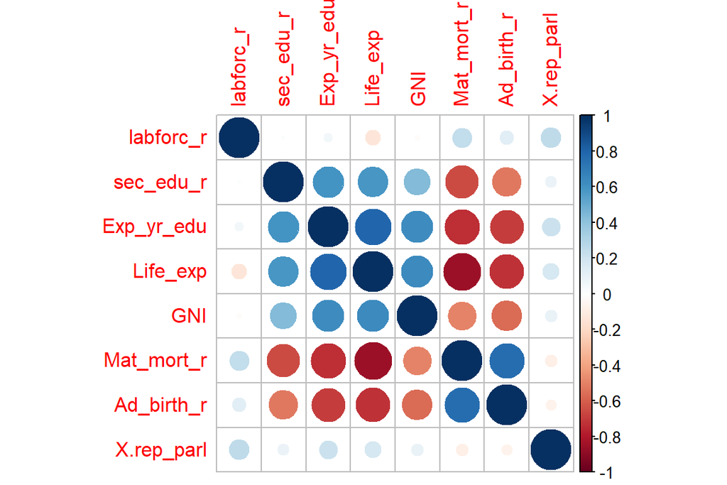

```r
library(tidyr)
library(corrplot)
cor_matrix <- cor(human) %>% round(2)
corrplot(cor_matrix, method="circle")
```

In general we may observe that we have rather strong positive and negative correlations between the variables. The ones that catch the eye especially are the strong negative correlation between life expectancy and maternal mortality ratio and the strong positive correlation between life expectancy and expected years of education.

Next, let’s perform a principal component analysis (PCA) on the data and draw a biplot of the PCA.

```r
humanpca <- prcomp(human)
sumr <- summary(humanpca)
sumr
```

```
## Importance of components:
##                              PC1      PC2   PC3   PC4   PC5   PC6    PC7    PC8
## Standard deviation     1.854e+04 185.5219 25.19 11.45 3.766 1.566 0.1912 0.1591
## Proportion of Variance 9.999e-01   0.0001  0.00  0.00 0.000 0.000 0.0000 0.0000
## Cumulative Proportion  9.999e-01   1.0000  1.00  1.00 1.000 1.000 1.0000 1.0000
```

```r
# Checking for the variability in the principal components by rounded percetanges of variance
pca_var <- round(100*sumr$importance[2, ], digits = 1)
pca_var
```

```
## PC1 PC2 PC3 PC4 PC5 PC6 PC7 PC8
## 100   0   0   0   0   0   0   0
```

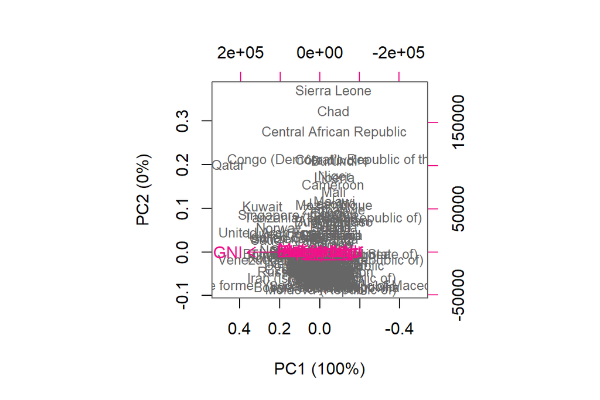

```r
# drawing a biplot of the data
pc_plot <- paste0(names(pca_var), " (", pca_var, "%)")
biplot(humanpca, cex = c(0.8, 1), col = c("grey40", "deeppink2"), xlab = pc_plot[1], ylab = pc_plot[2], xlim = c(0.5, -0.5))
```

Considering the data in its native form, principcal component 1 seems to explain nearly 100% of the variability of the data. Looking at the PCA biplot, especially the variable GNI seems to explain a lot of the variation in the data.

Next, let’s standardize the data and have an overview of it again.

```r
# standardizing the variables and checking the variance of each PCA again, drawing a new biplot of the standardized data
human_stdr <- scale(human)


pca_stdr <- prcomp(human_stdr)

s2 <- summary(pca_stdr)
s2
```

```
## Importance of components:
##                           PC1    PC2     PC3     PC4     PC5     PC6     PC7
## Standard deviation     2.0708 1.1397 0.87505 0.77886 0.66196 0.53631 0.45900
## Proportion of Variance 0.5361 0.1624 0.09571 0.07583 0.05477 0.03595 0.02634
## Cumulative Proportion  0.5361 0.6984 0.79413 0.86996 0.92473 0.96069 0.98702
##                            PC8
## Standard deviation     0.32224
## Proportion of Variance 0.01298
## Cumulative Proportion  1.00000
```

```r
pca_var2 <- round(100*s2$importance[2, ], digits = 1)
pca_var2
```

```
##  PC1  PC2  PC3  PC4  PC5  PC6  PC7  PC8
## 53.6 16.2  9.6  7.6  5.5  3.6  2.6  1.3
```

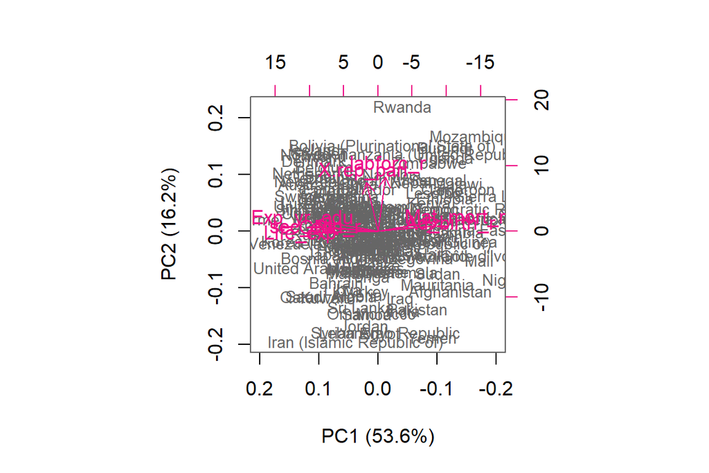

```r
# drawing a biplot of the data
pc_plot <- paste0(names(pca_var2), " (", pca_var2, "%)")
biplot(pca_stdr, cex = c(0.8, 1), col = c("grey40", "deeppink2"), xlab = pc_plot[1], ylab = pc_plot[2], xlim = c(0.2, -0.2))
```

Now when the data is standardized, PC1 explains only 53.6% of the variation in the data and PC2 seems to gain a much larger role with explaining about 16.2% of the variation. Looking at the new biplot the observations seem much more evenly distributed and the explanatory variables seem to have a much greater role in explaining the distribution of the data (not just GNI alone). For example life expectancy, expected years of education and population with secondary Education ratio between males and females seem to affect a large part of the distribution of the variables.

Next, we shall look at a different dataset called “tea” and perform a multiple correspondence analysis (MCA) on it.

```r
library(FactoMineR)
data(tea)
tea <- read.csv("https://raw.githubusercontent.com/KimmoVehkalahti/Helsinki-Open-Data-Science/master/datasets/tea.csv", stringsAsFactors = TRUE)
str(tea)
```

```
## 'data.frame':    300 obs. of  36 variables:
##  $ breakfast       : Factor w/ 2 levels "breakfast","Not.breakfast": 1 1 2 2 1 2 1 2 1 1 ...
##  $ tea.time        : Factor w/ 2 levels "Not.tea time",..: 1 1 2 1 1 1 2 2 2 1 ...
##  $ evening         : Factor w/ 2 levels "evening","Not.evening": 2 2 1 2 1 2 2 1 2 1 ...
##  $ lunch           : Factor w/ 2 levels "lunch","Not.lunch": 2 2 2 2 2 2 2 2 2 2 ...
##  $ dinner          : Factor w/ 2 levels "dinner","Not.dinner": 2 2 1 1 2 1 2 2 2 2 ...
##  $ always          : Factor w/ 2 levels "always","Not.always": 2 2 2 2 1 2 2 2 2 2 ...
##  $ home            : Factor w/ 2 levels "home","Not.home": 1 1 1 1 1 1 1 1 1 1 ...
##  $ work            : Factor w/ 2 levels "Not.work","work": 1 1 2 1 1 1 1 1 1 1 ...
##  $ tearoom         : Factor w/ 2 levels "Not.tearoom",..: 1 1 1 1 1 1 1 1 1 2 ...
##  $ friends         : Factor w/ 2 levels "friends","Not.friends": 2 2 1 2 2 2 1 2 2 2 ...
##  $ resto           : Factor w/ 2 levels "Not.resto","resto": 1 1 2 1 1 1 1 1 1 1 ...
##  $ pub             : Factor w/ 2 levels "Not.pub","pub": 1 1 1 1 1 1 1 1 1 1 ...
##  $ Tea             : Factor w/ 3 levels "black","Earl Grey",..: 1 1 2 2 2 2 2 1 2 1 ...
##  $ How             : Factor w/ 4 levels "alone","lemon",..: 1 3 1 1 1 1 1 3 3 1 ...
```

[output cut: 22 more lines]

I will perform MCA on a few of the variables in the data

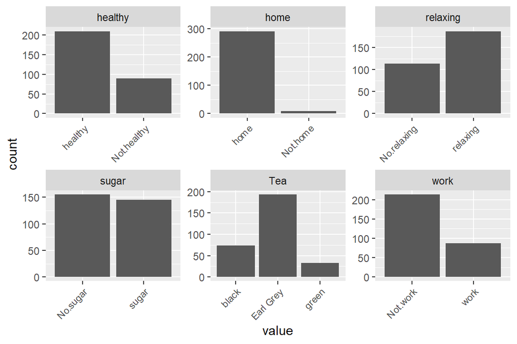

```r
library(dplyr)
library(tidyr)

# column names to keep in the dataset
keep_cols <- c("Tea", "relaxing", "healthy", "sugar", "home", "work")

tea2 <- dplyr::select(tea, one_of(keep_cols))

# visualizing the data
gather(tea2) %>% ggplot(aes(value)) +
facet_wrap("key", scales = "free") +
geom_bar() +
theme(axis.text.x = element_text(angle = 45, hjust = 1, size = 8))
```

From this general overview of the chosen variables, we can see that, for example, the responders in the data prefer to drink tea at home, mostly Earl Grey and find it relaxing/healthy. Interestingly sugar usage in tea is quite even.

```r
mca <- MCA(tea2)
```

[figure not shown]

[figure not shown]

[figure not shown]

```r
summary(mca)
```

```
##
## Call:
## MCA(X = tea2)
##
##
## Eigenvalues
##                        Dim.1   Dim.2   Dim.3   Dim.4   Dim.5   Dim.6   Dim.7
## Variance               0.230   0.194   0.185   0.173   0.148   0.120   0.116
## % of var.             19.755  16.655  15.885  14.807  12.691  10.262   9.945
## Cumulative % of var.  19.755  36.410  52.295  67.102  79.793  90.055 100.000
##
## Individuals (the 10 first)
##                Dim.1    ctr   cos2    Dim.2    ctr   cos2    Dim.3    ctr
## 1           | -0.275  0.109  0.068 |  0.149  0.038  0.020 | -0.061  0.007
## 2           | -0.686  0.680  0.433 |  0.241  0.099  0.053 |  0.361  0.235
## 3           |  0.038  0.002  0.002 | -0.515  0.455  0.318 |  0.551  0.545
## 4           |  0.211  0.064  0.086 | -0.327  0.184  0.208 | -0.469  0.396
## 5           |  0.057  0.005  0.004 |  0.040  0.003  0.002 | -0.215  0.083
## 6           | -0.201  0.058  0.081 | -0.236  0.095  0.112 | -0.047  0.004
## 7           | -0.201  0.058  0.081 | -0.236  0.095  0.112 | -0.047  0.004
## 8           | -0.722  0.754  0.573 | -0.343  0.202  0.129 |  0.028  0.001
## 9           |  0.057  0.005  0.004 |  0.040  0.003  0.002 | -0.215  0.083
## 10          | -0.722  0.754  0.573 | -0.343  0.202  0.129 |  0.028  0.001
##               cos2
## 1            0.003 |
## 2            0.120 |
## 3            0.364 |
## 4            0.426 |
## 5            0.057 |
## 6            0.004 |
## 7            0.004 |
## 8            0.001 |
## 9            0.057 |
## 10           0.001 |
##
## Categories (the 10 first)
##                 Dim.1     ctr    cos2  v.test     Dim.2     ctr    cos2  v.test
## black       |  -0.954  16.243   0.298  -9.442 |  -0.390   3.226   0.050  -3.863
## Earl Grey   |   0.548  13.975   0.542  12.728 |  -0.106   0.618   0.020  -2.457
## green       |  -1.066   9.032   0.140  -6.478 |   1.494  21.071   0.276   9.085
```

[output cut: 12 more lines]

```
## relaxing    |  -0.325   5.909   0.174  -7.222 |
## healthy     |   0.130   1.066   0.039   3.437 |
## Not.healthy |  -0.304   2.487   0.039  -3.437 |
## No.sugar    |   0.527  12.893   0.297   9.417 |
## sugar       |  -0.563  13.782   0.297  -9.417 |
## home        |  -0.038   0.123   0.046  -3.699 |
##
## Categorical variables (eta2)
##               Dim.1 Dim.2 Dim.3
## Tea         | 0.543 0.290 0.065 |
## relaxing    | 0.003 0.560 0.174 |
## healthy     | 0.116 0.111 0.039 |
## sugar       | 0.350 0.015 0.297 |
## home        | 0.274 0.077 0.046 |
## work        | 0.097 0.112 0.491 |
```

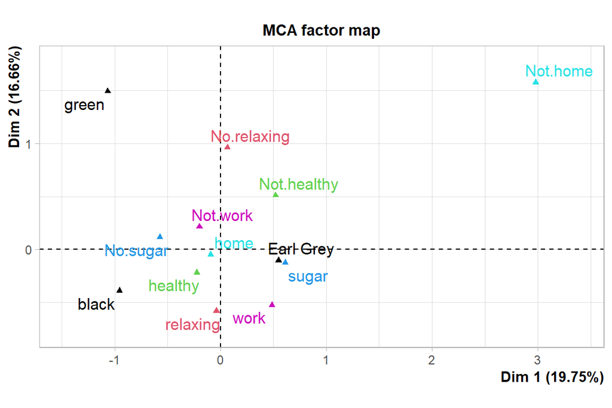

```r
plot(mca, invisible=c("ind"), habillage = "quali")
```